# DESeq2 tutorial

Bogdan Sieriebriennikov

December 2-3, 2021

## RNA-Seq of primary cultures of parathyroid tumors

We will be working with data that come with the `Bioconductor` package `parathyroidSE`. It is a [published](http://www.ncbi.nlm.nih.gov/pubmed/23024189) RNA-seq data set of primary cultures of parathyroid tumors. The count matrix (counts for each gene in each sample), as well as the metadata table are stored in an object of the type `RangedSummarizedExperiment`. Explore the object and the data.

```r
# load the parathyroidGenesSE data set
data("parathyroidGenesSE")
# assign to a variable named se
se <- parathyroidGenesSE

# se is an object of the class RangedSummarizedExperiment
class(se)
```

```
## [1] "RangedSummarizedExperiment"
## attr(,"package")
## [1] "SummarizedExperiment"
```

```r
# print the summary (default)
se
```

```
## class: RangedSummarizedExperiment
## dim: 63193 27
## metadata(1): MIAME
## assays(1): counts
## rownames(63193): ENSG00000000003 ENSG00000000005 ... LRG_98 LRG_99
## rowData names(0):
## colnames: NULL
## colData names(8): run experiment ... study sample
```

```r
# print the structure
str(se)
```

```
## Formal class 'RangedSummarizedExperiment' [package "SummarizedExperiment"] with 6 slots
##   ..@ rowRanges      :Formal class 'GRangesList' [package "GenomicRanges"] with 3 slots
##   .. .. ..@ elementMetadata:Formal class 'DataFrame' [package "IRanges"] with 6 slots
##   .. .. .. .. ..@ rownames       : NULL
##   .. .. .. .. ..@ nrows          : int 63193
##   .. .. .. .. ..@ listData       : Named list()
##   .. .. .. .. ..@ elementType    : chr "ANY"
##   .. .. .. .. ..@ elementMetadata: NULL
##   .. .. .. .. ..@ metadata       : list()
##   .. .. ..@ elementType    : chr "GRanges"
##   .. .. ..@ metadata       :List of 1
##   .. .. .. ..$ genomeInfo:List of 20
##   .. .. .. .. ..$ Db type                                 : chr "TranscriptDb"
##   .. .. .. .. ..$ Supporting package                      : chr "GenomicFeatures"
##   .. .. .. .. ..$ Data source                             : chr "BioMart"
##   .. .. .. .. ..$ Organism                                : chr "Homo sapiens"
##   .. .. .. .. ..$ Resource URL                            : chr "www.biomart.org:80"
##   .. .. .. .. ..$ BioMart database                        : chr "ensembl"
##   .. .. .. .. ..$ BioMart database version                : chr "ENSEMBL GENES 72 (SANGER UK)"
##   .. .. .. .. ..$ BioMart dataset                         : chr "hsapiens_gene_ensembl"
##   .. .. .. .. ..$ BioMart dataset description             : chr "Homo sapiens genes (GRCh37.p11)"
##   .. .. .. .. ..$ BioMart dataset version                 : chr "GRCh37.p11"
##   .. .. .. .. ..$ Full dataset                            : chr "yes"
##   .. .. .. .. ..$ miRBase build ID                        : chr NA
##   .. .. .. .. ..$ transcript_nrow                         : chr "213140"
##   .. .. .. .. ..$ exon_nrow                               : chr "737783"
##   .. .. .. .. ..$ cds_nrow                                : chr "531154"
##   .. .. .. .. ..$ Db created by                           : chr "GenomicFeatures package from Bioconductor"
##   .. .. .. .. ..$ Creation time                           : chr "2013-07-30 17:30:25 +0200 (Tue, 30 Jul 2013)"
##   .. .. .. .. ..$ GenomicFeatures version at creation time: chr "1.13.21"
##   .. .. .. .. ..$ RSQLite version at creation time        : chr "0.11.4"
##   .. .. .. .. ..$ DBSCHEMAVERSION                         : chr "1.0"
##   .. .. ..$ unlistData  :Formal class 'GRanges' [package "GenomicRanges"] with 7 slots
```

```
##   .. .. .. .. ..@ seqnames       :Formal class 'Rle' [package "IRanges"] with 4 slots
##   .. .. .. .. .. .. ..@ values         : Factor w/ 580 levels "1","2","3","4",..: 23 20 1 6 1 23 6 3 7 12 ...
##   .. .. .. .. .. .. ..@ lengths        : int [1:47032] 27 29 172 78 75 27 4 41 189 78 ...
##   .. .. .. .. .. .. ..@ elementMetadata: NULL
##   .. .. .. .. .. .. ..@ metadata       : list()
##   .. .. .. .. ..@ strand         :Formal class 'Rle' [package "IRanges"] with 4 slots
##   .. .. .. .. .. .. ..@ values         : Factor w/ 3 levels "+","-","*": 2 1 2 1 2 1 2 1 2 1 ...
##   .. .. .. .. .. .. ..@ lengths        : int [1:31306] 17 10 58 72 26 45 66 12 42 33 ...
##   .. .. .. .. .. .. ..@ elementMetadata: NULL
##   .. .. .. .. .. .. ..@ metadata       : list()
##   .. .. .. .. ..@ ranges         :Formal class 'IRanges' [package "IRanges"] with 6 slots
##   .. .. .. .. .. .. ..@ start          : int [1:737783] 99883667 99885756 99887482 99887538 99888402 99888402 99888439 99888928 99888928 99890175 ...
##   .. .. .. .. .. .. ..@ width          : int [1:737783] 1317 108 84 28 135 135 98 99 99 75 ...
##   .. .. .. .. .. .. ..@ NAMES          : NULL
##   .. .. .. .. .. .. ..@ elementType    : chr "integer"
##   .. .. .. .. .. .. ..@ elementMetadata: NULL
##   .. .. .. .. .. .. ..@ metadata       : list()
##   .. .. .. .. ..@ elementMetadata:Formal class 'DataFrame' [package "IRanges"] with 6 slots
##   .. .. .. .. .. .. ..@ rownames       : NULL
##   .. .. .. .. .. .. ..@ nrows          : int 737783
##   .. .. .. .. .. .. ..@ listData       :List of 2
##   .. .. .. .. .. .. .. ..$ exon_id  : int [1:737783] 664095 664096 664097 664098 664099 664100 664101 664103 664102 664104 ...
##   .. .. .. .. .. .. .. ..$ exon_name: chr [1:737783] "ENSE00001459322" "ENSE00000868868" "ENSE00000401072" "ENSE00001849132" ...
##   .. .. .. .. .. .. ..@ elementType    : chr "ANY"
##   .. .. .. .. .. .. ..@ elementMetadata: NULL
##   .. .. .. .. .. .. ..@ metadata       : list()
##   .. .. .. .. ..@ seqinfo        :Formal class 'Seqinfo' [package "GenomicRanges"] with 4 slots
##   .. .. .. .. .. .. ..@ seqnames   : chr [1:580] "1" "2" "3" "4" ...
##   .. .. .. .. .. .. ..@ seqlengths : int [1:580] 249250621 243199373 198022430 191154276 180915260 171115067 159138663 146364022 141213431 135534747 ...
##   .. .. .. .. .. .. ..@ is_circular: logi [1:580] FALSE FALSE FALSE FALSE FALSE FALSE ...
##   .. .. .. .. .. .. ..@ genome     : chr [1:580] NA NA NA NA ...
##   .. .. .. .. ..@ metadata       : list()
##   .. .. .. .. ..@ NA             : NULL
##   .. .. ..$ partitioning:Formal class 'PartitioningByEnd' [package "IRanges"] with 5 slots
##   .. .. .. .. ..@ end            : int [1:63193] 17 27 56 85 157 183 228 240 294 306 ...
##   .. .. .. .. ..@ NAMES          : chr [1:63193] "ENSG00000000003" "ENSG00000000005" "ENSG00000000419" "ENSG00000000457" ...
##   .. .. .. .. ..@ elementType    : chr "integer"
##   .. .. .. .. ..@ elementMetadata: NULL
##   .. .. .. .. ..@ metadata       : list()
##   ..@ colData        :Formal class 'DataFrame' [package "IRanges"] with 6 slots
```

[output cut: 34 more lines]

```
##   .. .. .. ..@ contact          : chr "Mikael Huss"
##   .. .. .. ..@ title            : chr "DPN and Tamoxifen treatments of parathyroid adenoma cells"
##   .. .. .. ..@ abstract         : chr "Primary hyperparathyroidism (PHPT) is most frequently present in postmenopausal women. Although the involvement"| __truncated__
##   .. .. .. ..@ url              : chr "http://www.ncbi.nlm.nih.gov/geo/query/acc.cgi?acc=GSE37211"
##   .. .. .. ..@ pubMedIds        : chr "23024189"
##   .. .. .. ..@ samples          : list()
##   .. .. .. ..@ hybridizations   : list()
##   .. .. .. ..@ normControls     : list()
##   .. .. .. ..@ preprocessing    : list()
##   .. .. .. ..@ other            : list()
##   .. .. .. ..@ .__classVersion__:Formal class 'Versions' [package "Biobase"] with 1 slot
##   .. .. .. .. .. ..@ .Data:List of 2
##   .. .. .. .. .. .. ..$ : int [1:3] 1 0 0
##   .. .. .. .. .. .. ..$ : int [1:3] 1 1 0
##   .. .. .. .. .. ..$ names: chr [1:2] "MIAxE" "MIAME"
```

```r
# look at the raw counts
head( se@assays[["data"]]@listData[["counts"]] ) # directly
```

```
##      [,1] [,2] [,3] [,4] [,5] [,6] [,7] [,8] [,9] [,10] [,11] [,12] [,13] [,14]
## [1,]  792 1064  444  953  519  855  413  365  278  1173   463   316   987   424
## [2,]    4    1    2    3    3    1    0    1    0     0     0     0     0     0
## [3,]  294  282  164  263  179  217  277  204  189   601   257   183   588   275
## [4,]  156  184   93  145   75  122  228  171  116   422   182   122   441   211
## [5,]  396  207  210  212  221  173  611  199  426  1391   286   417  1452   238
## [6,]    3    8    2    5    0    4   13   22    3    38    13    10    26    13
##      [,15] [,16] [,17] [,18] [,19] [,20] [,21] [,22] [,23] [,24] [,25] [,26]
## [1,]   305   391   586   714   957   346   433   402   277   511   366   271
## [2,]     0     0     0     0     1     0     0     0     0     0     0     0
## [3,]   263   281   406   568   764   288   259   250   147   271   227   197
## [4,]   131   115   196   266   347   133   168   148    83   184   136   118
## [5,]   188   102   389   294   778   162    85   339    75   154   314   117
## [6,]     7     3    10    18    15     7     8     7     5    13     8     7
##      [,27]
## [1,]   492
## [2,]     0
## [3,]   363
## [4,]   195
## [5,]   233
## [6,]     8
```

```r
head( assay(se) ) # using the assay() method
```

```
##                 [,1] [,2] [,3] [,4] [,5] [,6] [,7] [,8] [,9] [,10] [,11] [,12]
## ENSG00000000003  792 1064  444  953  519  855  413  365  278  1173   463   316
## ENSG00000000005    4    1    2    3    3    1    0    1    0     0     0     0
## ENSG00000000419  294  282  164  263  179  217  277  204  189   601   257   183
## ENSG00000000457  156  184   93  145   75  122  228  171  116   422   182   122
## ENSG00000000460  396  207  210  212  221  173  611  199  426  1391   286   417
## ENSG00000000938    3    8    2    5    0    4   13   22    3    38    13    10
##                 [,13] [,14] [,15] [,16] [,17] [,18] [,19] [,20] [,21] [,22]
## ENSG00000000003   987   424   305   391   586   714   957   346   433   402
## ENSG00000000005     0     0     0     0     0     0     1     0     0     0
## ENSG00000000419   588   275   263   281   406   568   764   288   259   250
## ENSG00000000457   441   211   131   115   196   266   347   133   168   148
## ENSG00000000460  1452   238   188   102   389   294   778   162    85   339
## ENSG00000000938    26    13     7     3    10    18    15     7     8     7
##                 [,23] [,24] [,25] [,26] [,27]
## ENSG00000000003   277   511   366   271   492
## ENSG00000000005     0     0     0     0     0
## ENSG00000000419   147   271   227   197   363
## ENSG00000000457    83   184   136   118   195
## ENSG00000000460    75   154   314   117   233
## ENSG00000000938     5    13     8     7     8
```

```r
# look at the metadata
se@colData # directly
```

```
## DataFrame with 27 rows and 8 columns
##             run experiment  patient treatment     time submission     study
##     <character>   <factor> <factor>  <factor> <factor>   <factor>  <factor>
## 1     SRR479052  SRX140503        1   Control      24h  SRA051611 SRP012167
## 2     SRR479053  SRX140504        1   Control      48h  SRA051611 SRP012167
## 3     SRR479054  SRX140505        1   DPN          24h  SRA051611 SRP012167
## 4     SRR479055  SRX140506        1   DPN          48h  SRA051611 SRP012167
## 5     SRR479056  SRX140507        1   OHT          24h  SRA051611 SRP012167
## ...         ...        ...      ...       ...      ...        ...       ...
## 23    SRR479074  SRX140523        4       DPN      48h  SRA051611 SRP012167
## 24    SRR479075  SRX140523        4       DPN      48h  SRA051611 SRP012167
## 25    SRR479076  SRX140524        4       OHT      24h  SRA051611 SRP012167
## 26    SRR479077  SRX140525        4       OHT      48h  SRA051611 SRP012167
## 27    SRR479078  SRX140525        4       OHT      48h  SRA051611 SRP012167
##        sample
##      <factor>
## 1   SRS308865
## 2   SRS308866
## 3   SRS308867
## 4   SRS308868
## 5   SRS308869
## ...       ...
## 23  SRS308885
## 24  SRS308885
## 25  SRS308886
## 26  SRS308887
## 27  SRS308887
```

```r
colData(se) # using the colData() method
```

```
## DataFrame with 27 rows and 8 columns
##             run experiment  patient treatment     time submission     study
##     <character>   <factor> <factor>  <factor> <factor>   <factor>  <factor>
## 1     SRR479052  SRX140503        1   Control      24h  SRA051611 SRP012167
## 2     SRR479053  SRX140504        1   Control      48h  SRA051611 SRP012167
## 3     SRR479054  SRX140505        1   DPN          24h  SRA051611 SRP012167
## 4     SRR479055  SRX140506        1   DPN          48h  SRA051611 SRP012167
## 5     SRR479056  SRX140507        1   OHT          24h  SRA051611 SRP012167
## ...         ...        ...      ...       ...      ...        ...       ...
## 23    SRR479074  SRX140523        4       DPN      48h  SRA051611 SRP012167
## 24    SRR479075  SRX140523        4       DPN      48h  SRA051611 SRP012167
## 25    SRR479076  SRX140524        4       OHT      24h  SRA051611 SRP012167
## 26    SRR479077  SRX140525        4       OHT      48h  SRA051611 SRP012167
## 27    SRR479078  SRX140525        4       OHT      48h  SRA051611 SRP012167
##        sample
##      <factor>
## 1   SRS308865
## 2   SRS308866
## 3   SRS308867
## 4   SRS308868
## 5   SRS308869
## ...       ...
## 23  SRS308885
## 24  SRS308885
## 25  SRS308886
## 26  SRS308887
## 27  SRS308887
```

## Exploratory analyses

Before proceeding to differential expression testing, it is important to explore your data. You might want to know how different or similar the different samples are, get some idea about the major sources of variation in your data, and detect possible outlier samples.

### Heatmap of sample distances

Euclidean distance is a simple measure of overall dissimilarity between a pair of samples. Let us calculate and plot pairwise distances between all samples in the data. It is important to **transform** (`DESeq2` has functions for regularized log and variance stabilizing transformation) the counts before doing so. Otherwise, there is a risk that a small number of highly expressed genes will drive the general pattern.

```r
# convert the RangedSummarizedExperiment object to a DESeqDataSet object
dds <- DESeqDataSet(se = se,
                    design = ~ 1) # ignore the design parameter for now

# apply variance stabilizing transformation
dds_transformed <- vst(dds)
# extract the transformed count matrix
transformed_counts <- assay(dds_transformed)
# transpose and calculate Euclidean distances
# (transposition is necessary to calculate distances between samples and not between genes)
distances <- dist(t(transformed_counts))
distances
```

```
##            1         2         3         4         5         6         7
## 2   40.68087
## 3   34.12075  44.33205
## 4   39.29031  31.53883  40.81089
## 5   32.36381  44.10530  36.36904  42.68089
## 6   38.70560  30.07671  43.40134  32.76773  42.20075
## 7   77.55091  77.70213  78.76674  78.22367  79.32764  78.36048
## 8   83.04497  76.72573  84.59852  79.67399  85.31694  78.85239  40.20968
## 9   79.61879  80.80951  80.45468  80.28043  81.78674  80.79512  33.95574
## 10  77.32416  78.22028  78.39744  77.72372  79.38483  78.33766  28.68696
## 11  81.34501  75.95196  82.45186  77.53848  83.74553  77.37808  37.30856
## 12  78.57950  79.41111  79.68053  79.84460  80.42796  79.66053  33.04199
## 13  76.51676  77.27090  77.69622  77.72359  78.34395  77.68988  28.30876
## 14  81.24962  75.13331  82.82947  78.17955  83.41762  77.29066  39.42672
## 15  99.45436  96.37417 102.20082  97.94283 101.45518  98.10227  99.43193
## 16 103.99945  96.82166 106.42180 100.11579 105.43677  99.66886 104.36151
## 17  97.82431  95.28262 100.10654  96.60561  99.37398  96.70764  97.90298
## 18 102.09576  95.13579 104.63476  97.75178 103.70629  97.72674 103.14981
## 19  98.22004  95.24802 100.79455  96.67614  99.74026  97.02404  99.02418
## 20 103.46999  97.42713 106.07779  99.98737 104.90495  99.81334 105.23911
## 21  93.51816  86.43829  96.26902  89.84066  95.16754  89.54429  90.86931
## 22  84.26173  83.06804  86.49715  83.29362  86.00489  83.83682  81.39225
## 23  91.63972  85.12514  93.84348  87.34249  93.19877  87.74817  88.55102
## 24  90.28804  83.64787  92.89308  85.89031  92.14904  86.31367  87.51774
## 25  86.33795  85.91424  89.14953  86.73525  88.02614  86.73936  84.68702
## 26  92.58804  87.57313  95.80949  90.22608  94.21949  90.13581  91.31415
## 27  91.66949  86.37274  94.99489  89.05825  93.29851  88.98682  90.62680
##            8         9        10        11        12        13        14
## 2
## 3
## 4
## 5
## 6
## 7
## 8
## 9   45.17314
## 10  41.16325  30.30607
## 11  32.76320  40.71518  36.12255
## 12  43.73283  35.70259  31.04216  40.03760
## 13  40.31642  32.09313  24.36265  36.37836  29.61389
```

[output cut: 53 more lines]

```
## 13
## 14
## 15
## 16
## 17
## 18
## 19
## 20
## 21
## 22
## 23  45.38179
## 24  42.70127  33.72586
## 25  33.88426  47.79262  45.01209
## 26  46.59471  40.47219  37.05145  45.18124
## 27  44.59068  38.08088  33.53630  42.87296  31.30093
```

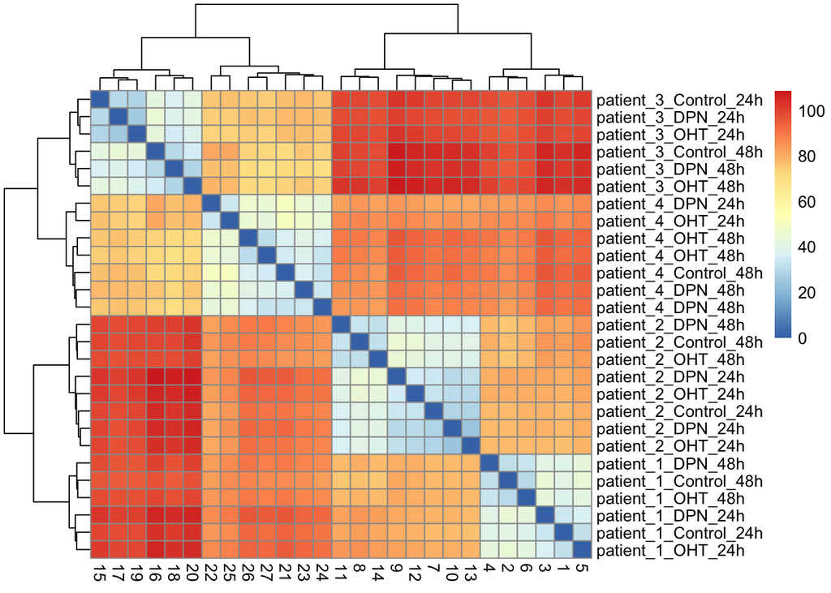

```r
# convert the dist object to a matrix
distances <- as.matrix(distances)
# add informative row names (optional, but recommended)
rownames(distances) <- paste("patient",
                             dds$patient,
                             dds$treatment,
                             dds$time,
                             sep = "_")

# plot as a heatmap
pheatmap(distances)
```

It appears that samples taken from the same patient are much more similar to each other than to any sample from any other patient, regardless of the time point or the treatment applied. Therefore, it is reasonable to expect that our data contain a lot of variation between patients, something that we will actually have to account for later to see the effect of treatment! Additionally, within each patient “block”, the two time points, but not the different treatments, are usually separated, suggesting that collection time is the next major source of variance in the data.

### PCA of samples

Another way to explore the relationship between samples and the sources of variation in the data is principal component analysis (PCA).

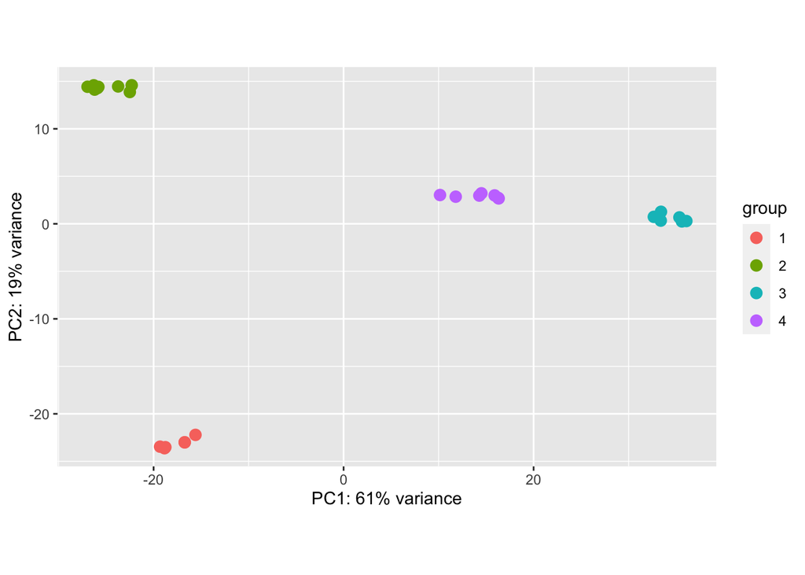

```r
# plot PC1 and PC2, color by patient
plotPCA(dds_transformed,
        intgroup = "patient")
```

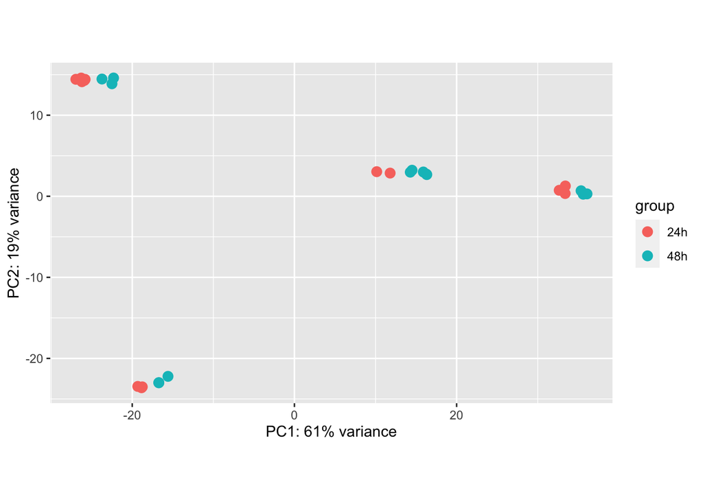

```r
# plot PC1 and PC2, color by time
plotPCA(dds_transformed,
        intgroup = "time")
```

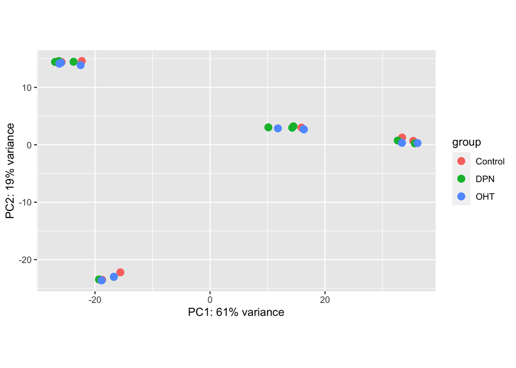

```r
# plot PC1 and PC2, color by treatment
plotPCA(dds_transformed,
        intgroup = "treatment")
```

Once again, we can attribute most of the variation in our data to differences between patients. Unfortunately, the principal components 1 and 2, which explain the majority of variation, do not separate between treatments at all. As for the time points, they appear slightly shifted in relation to each other along PC1, but they are still not fully separated. In such situations, we might want to explore other principal components, as long as they explain a decent amount of variation in the data. Unfortunately, there is no way to plot them using `plotPCA()` directly. There are two solutions: 1. Run the base R function `prcomp()` on the transformed counts, extract coordinates of the desired components from the output and write a code to plot them. 2. Hack `plotPCA()`.

In fact, `DESeq2` developers openly invite you to tweak `plotPCA()` (see Note in the function help file). Just type `DESeq2:::plotPCA.DESeqTransform` in the console to get the function source code:

```
function (object, intgroup = "condition", ntop = 500, returnData = FALSE)
{
    rv <- rowVars(assay(object))
    select <- order(rv, decreasing = TRUE)[seq_len(min(ntop,
        length(rv)))]
    pca <- prcomp(t(assay(object)[select, ]))
    percentVar <- pca$sdev^2/sum(pca$sdev^2)
    if (!all(intgroup %in% names(colData(object)))) {
        stop("the argument 'intgroup' should specify columns of colData(dds)")
    }
    intgroup.df <- as.data.frame(colData(object)[, intgroup,
        drop = FALSE])
    group <- if (length(intgroup) > 1) {
        factor(apply(intgroup.df, 1, paste, collapse = ":"))
    }
    else {
        colData(object)[[intgroup]]
    }
    d <- data.frame(PC1 = pca$x[, 1], PC2 = pca$x[, 2], group = group,
        intgroup.df, name = colnames(object))
    if (returnData) {
        attr(d, "percentVar") <- percentVar[1:2]
        return(d)
    }
    ggplot(data = d, aes_string(x = "PC1", y = "PC2", color = "group")) +
        geom_point(size = 3) + xlab(paste0("PC1: ", round(percentVar[1] *
        100), "% variance")) + ylab(paste0("PC2: ", round(percentVar[2] *
        100), "% variance")) + coord_fixed()
}
```

It should be pretty obvious which parts you should modify to be able to print other PCs than 1 and 2. Ideally, you should create a new custom function to plot any two PCs, where the specific PCs to plot are set as input parameters (kudos to *Kris*).

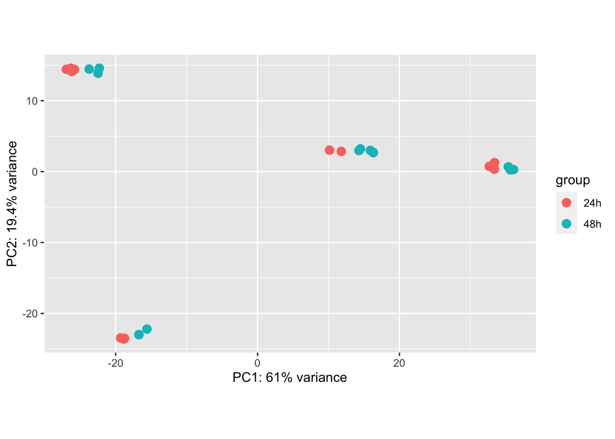

```r
# create a new custom function
plotPCA_custom <- function (object,
                            intgroup = "condition",
                            ntop = 500,
                            returnData = FALSE,
                            dim1 = 1,
                            dim2 = 2)
{
  rv <- rowVars(assay(object))
  select <- order(rv, decreasing = TRUE)[seq_len(min(ntop,
                                                     length(rv)))]
  pca <- prcomp(t(assay(object)[select, ]))
  percentVar <- pca$sdev^2/sum(pca$sdev^2)
  if (!all(intgroup %in% names(colData(object)))) {
    stop("the argument 'intgroup' should specify columns of colData(dds)")
  }
  intgroup.df <- as.data.frame(colData(object)[, intgroup,
                                               drop = FALSE])
  group <- if (length(intgroup) > 1) {
    factor(apply(intgroup.df, 1, paste, collapse = ":"))
  }
  else {
    colData(object)[[intgroup]]
  }
  d <- data.frame(PC1 = pca$x[, dim1],
                  PC2 = pca$x[, dim2],
                  group = group, intgroup.df, name = colnames(object))
  if (returnData) {
    attr(d, "percentVar") <- percentVar[dim1:dim2]
    return(d)
  }
  ggplot(data = d, aes_string(x = "PC1", y = "PC2", color = "group")) +
    geom_point(size = 3) +
    xlab(paste0("PC",dim1,": ", round(percentVar[dim1] * 100, 1), "% variance")) +
    ylab(paste0("PC",dim2,": ", round(percentVar[dim2] * 100, 1), "% variance")) +
    coord_fixed()
}

# test and explore the different PCs
plotPCA_custom(dds_transformed,
               intgroup = "time")
```

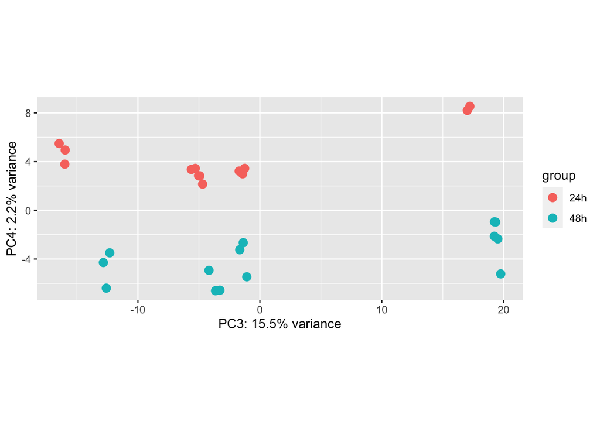

```r
plotPCA_custom(dds_transformed,
               intgroup = "time",
               dim1 = 3,
               dim2 = 4)
```

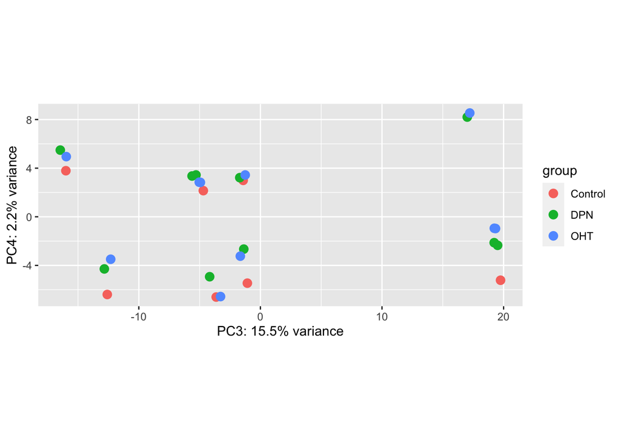

```r
plotPCA_custom(dds_transformed,
               intgroup = "treatment",
               dim1 = 3,
               dim2 = 4)
```

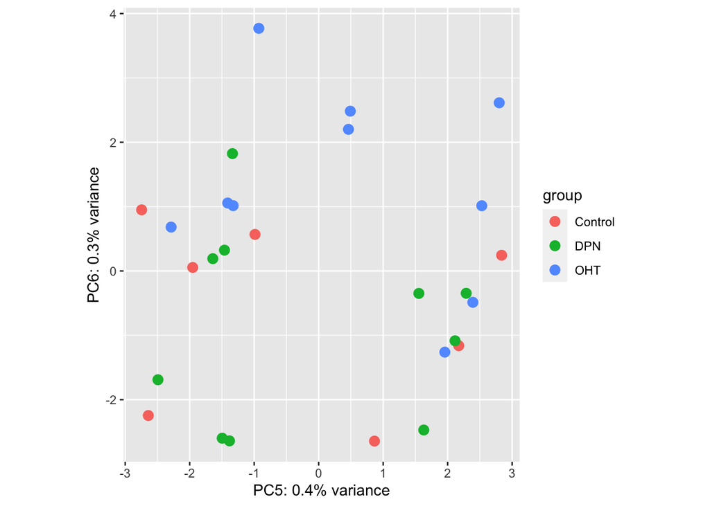

```r
plotPCA_custom(dds_transformed,
               intgroup = "treatment",
               dim1 = 5,
               dim2 = 6)
```

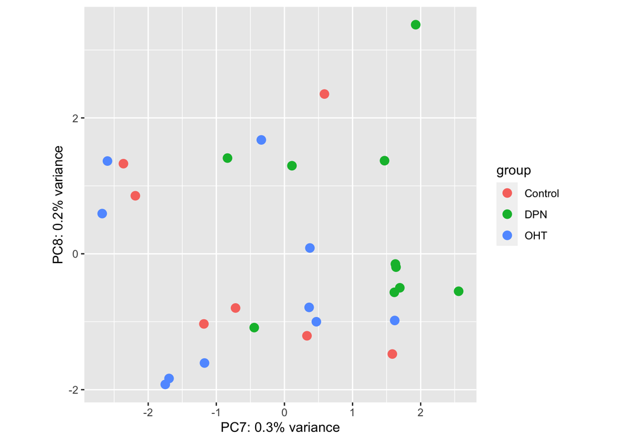

```r
plotPCA_custom(dds_transformed,
               intgroup = "treatment",
               dim1 = 7,
               dim2 = 8)
```

Turns out, PC4 separates between the time points really well! However, none of the principal components 1-8 separates the treatments. We can interpret it as treatment contributing little to the variation between samples. This does not automatically mean that treatment has no effect at all, but it is unlikely that it has a large global effect on the transcriptome.

## Differential expression testing

### Difference between the time points

Even though most variation in our data is attributed to differences between individual patients, we were still able to separate between the time points in both the distance heatmap and the PC plots. Therefore, we should expect a considerable number of genes differentially expressed between the time points. Let us do a simple pairwise comparison.

```r
# create a new DESeqDataSet object, pass the desired formula to the design parameter
dds <- DESeqDataSet(se = se,
                    design = ~ time) # important! this is where you specify the grouping variable for DE testing

# fit the model
dds_de <- DESeq(dds)
```

```
## -- replacing outliers and refitting for 159 genes
## -- DESeq argument 'minReplicatesForReplace' = 7
## -- original counts are preserved in counts(dds)
```

```r
# calculate stats
res <- results(dds_de)
res
```

```
## log2 fold change (MLE): time 48h vs 24h
## Wald test p-value: time 48h vs 24h
## DataFrame with 63193 rows and 6 columns
##                   baseMean log2FoldChange     lfcSE      stat      pvalue
##                  <numeric>      <numeric> <numeric> <numeric>   <numeric>
## ENSG00000000003 523.359728      0.0505895 0.1730194  0.292392 7.69987e-01
## ENSG00000000005   0.660925     -0.9315544 1.3315421 -0.699606 4.84174e-01
## ENSG00000000419 277.455267     -0.0572008 0.0519041 -1.102048 2.70441e-01
## ENSG00000000457 165.908635     -0.0495162 0.1240205 -0.399258 6.89703e-01
## ENSG00000000460 314.483127     -1.3416345 0.2083554 -6.439162 1.20135e-10
## ...                    ...            ...       ...       ...         ...
## LRG_94                   0             NA        NA        NA          NA
## LRG_96                   0             NA        NA        NA          NA
## LRG_97                   0             NA        NA        NA          NA
## LRG_98                   0             NA        NA        NA          NA
## LRG_99                   0             NA        NA        NA          NA
##                        padj
##                   <numeric>
## ENSG00000000003 9.11412e-01
## ENSG00000000005          NA
## ENSG00000000419 5.76570e-01
## ENSG00000000457 8.72827e-01
## ENSG00000000460 3.46571e-08
## ...                     ...
## LRG_94                   NA
## LRG_96                   NA
## LRG_97                   NA
## LRG_98                   NA
## LRG_99                   NA
```

```r
# keep significantly DE genes only
significant_indices <- res$padj < 0.05 & !is.na(res$padj)
res_filtered <- res[significant_indices, ]
res_filtered
```

```
## log2 fold change (MLE): time 48h vs 24h
## Wald test p-value: time 48h vs 24h
## DataFrame with 1578 rows and 6 columns
##                  baseMean log2FoldChange     lfcSE      stat      pvalue
##                 <numeric>      <numeric> <numeric> <numeric>   <numeric>
## ENSG00000000460   314.483      -1.341634 0.2083554  -6.43916 1.20135e-10
## ENSG00000001497   380.827      -0.296619 0.0630870  -4.70175 2.57938e-06
## ENSG00000001630   376.241       0.266677 0.0910892   2.92765 3.41537e-03
## ENSG00000003393   413.410       0.212640 0.0570776   3.72546 1.94956e-04
## ENSG00000003400   156.370      -0.559207 0.1067449  -5.23872 1.61691e-07
## ...                   ...            ...       ...       ...         ...
## ENSG00000270081   62.5133       0.309648  0.106433   2.90933 3.62208e-03
## ENSG00000270101   20.7746      -0.586673  0.150300  -3.90336 9.48663e-05
## ENSG00000271122   73.5334      -0.513217  0.158712  -3.23364 1.22223e-03
## ENSG00000271643   30.2448      -0.385443  0.130104  -2.96258 3.05076e-03
## ENSG00000271646   16.1016      -1.047857  0.247324  -4.23678 2.26752e-05
##                        padj
##                   <numeric>
## ENSG00000000460 3.46571e-08
## ENSG00000001497 1.77543e-04
## ENSG00000001630 4.49057e-02
## ENSG00000003393 5.59131e-03
## ENSG00000003400 1.76217e-05
## ...                     ...
## ENSG00000270081  0.04680919
## ENSG00000270101  0.00324215
## ENSG00000271122  0.02209374
## ENSG00000271643  0.04167607
## ENSG00000271646  0.00101419
```

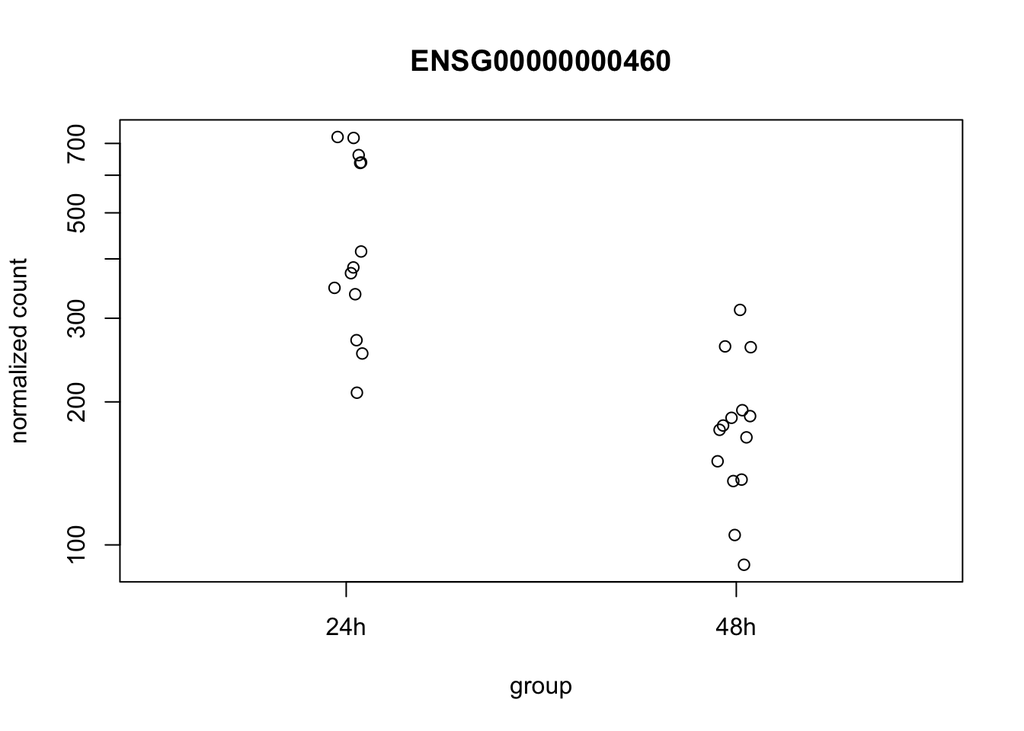

```r
# sanity check - plot the counts for a randomly picked (first) gene in the table
# and see if the pattern makes sense in the light of the estimated LFC value
plotCounts(dds_de,
           gene = rownames(res_filtered)[1],
           intgroup = "time")
```

### Difference between the treatments - “simple” design

So, are any genes differentially expressed between the treatments?

```r
# create a new DESeqDataSet object, pass the desired formula to the design parameter
dds <- DESeqDataSet(se = se,
                    design = ~ treatment) # important!

# fit the model
dds_de <- DESeq(dds)
```

```
## -- replacing outliers and refitting for 15 genes
## -- DESeq argument 'minReplicatesForReplace' = 7
## -- original counts are preserved in counts(dds)
```

```r
# calculate stats
res <- results(dds_de)
res
```

```
## log2 fold change (MLE): treatment OHT vs Control
## Wald test p-value: treatment OHT vs Control
## DataFrame with 63193 rows and 6 columns
##                   baseMean log2FoldChange     lfcSE      stat    pvalue
##                  <numeric>      <numeric> <numeric> <numeric> <numeric>
## ENSG00000000003 523.359728     -0.0368111  0.226284 -0.162677  0.870773
## ENSG00000000005   0.660925     -0.7234640  1.751438 -0.413069  0.679556
## ENSG00000000419 277.455267      0.0624121  0.067520  0.924350  0.355304
## ENSG00000000457 165.908635     -0.0346749  0.161669 -0.214480  0.830172
## ENSG00000000460 314.483127      0.3676239  0.414943  0.885962  0.375638
## ...                    ...            ...       ...       ...       ...
## LRG_94                   0             NA        NA        NA        NA
## LRG_96                   0             NA        NA        NA        NA
## LRG_97                   0             NA        NA        NA        NA
## LRG_98                   0             NA        NA        NA        NA
## LRG_99                   0             NA        NA        NA        NA
##                      padj
##                 <numeric>
## ENSG00000000003  0.999962
## ENSG00000000005  0.999962
## ENSG00000000419  0.999962
## ENSG00000000457  0.999962
## ENSG00000000460  0.999962
## ...                   ...
## LRG_94                 NA
## LRG_96                 NA
## LRG_97                 NA
## LRG_98                 NA
## LRG_99                 NA
```

```r
# keep significantly DE genes only
significant_indices <- res$padj < 0.05 & !is.na(res$padj)
res_filtered <- res[significant_indices, ]
res_filtered
```

```
## log2 fold change (MLE): treatment OHT vs Control
## Wald test p-value: treatment OHT vs Control
## DataFrame with 0 rows and 6 columns
```

```r
# the results above are ONLY for the OHT vs Control comparison
# to calculate stats for the DPN vs Control comparison, you have to set the contrast parameter

# calculate stats
res <- results(dds_de,
               contrast = c("treatment", "DPN", "Control")) # kind of a weird but a well-functioning way to specify the contrast
res
```

```
## log2 fold change (MLE): treatment DPN vs Control
## Wald test p-value: treatment DPN vs Control
## DataFrame with 63193 rows and 6 columns
##                   baseMean log2FoldChange     lfcSE       stat    pvalue
##                  <numeric>      <numeric> <numeric>  <numeric> <numeric>
## ENSG00000000003 523.359728     -0.0212380 0.2262641 -0.0938637  0.925217
## ENSG00000000005   0.660925     -0.6545459 1.7463754 -0.3748025  0.707807
## ENSG00000000419 277.455267     -0.0115706 0.0676664 -0.1709939  0.864229
## ENSG00000000457 165.908635     -0.0872325 0.1617568 -0.5392819  0.589692
## ENSG00000000460 314.483127      0.3093592 0.4149683  0.7455007  0.455969
## ...                    ...            ...       ...        ...       ...
## LRG_94                   0             NA        NA         NA        NA
## LRG_96                   0             NA        NA         NA        NA
## LRG_97                   0             NA        NA         NA        NA
## LRG_98                   0             NA        NA         NA        NA
## LRG_99                   0             NA        NA         NA        NA
##                      padj
##                 <numeric>
## ENSG00000000003         1
## ENSG00000000005         1
## ENSG00000000419         1
## ENSG00000000457         1
## ENSG00000000460         1
## ...                   ...
## LRG_94                 NA
## LRG_96                 NA
## LRG_97                 NA
## LRG_98                 NA
## LRG_99                 NA
```

```r
# keep significantly DE genes only
significant_indices <- res$padj < 0.05 & !is.na(res$padj)
res_filtered <- res[significant_indices, ]
res_filtered
```

```
## log2 fold change (MLE): treatment DPN vs Control
## Wald test p-value: treatment DPN vs Control
## DataFrame with 0 rows and 6 columns
```

Hmmmmm…

### Difference between the treatments - accounting for interindividual variation

Do you remember that most variation in our data is attributed to different patients? Perhaps it is masking the effect of treatment! We can account for inter-individual variation before testing for differences between treatments by passing a more complex formula to the design argument. **Order matters:** by default, `results()` will calculate the Wald statistics and the p-values for the last variable in the formula after accounting for the affect of the preceding variable(s).

```r
# create a new DESeqDataSet object, pass the desired formula to the design parameter
dds <- DESeqDataSet(se = se,
                    design = ~ patient + treatment) # important!

# fit the model
dds_de <- DESeq(dds)
# calculate stats
res <- results(dds_de)
res
```

```
## log2 fold change (MLE): treatment OHT vs Control
## Wald test p-value: treatment OHT vs Control
## DataFrame with 63193 rows and 6 columns
##                   baseMean log2FoldChange     lfcSE      stat    pvalue
##                  <numeric>      <numeric> <numeric> <numeric> <numeric>
## ENSG00000000003 523.359728      0.0133040 0.0638620  0.208324  0.834976
## ENSG00000000005   0.660925     -0.2279829 1.3410881 -0.169998  0.865011
## ENSG00000000419 277.455267      0.0424908 0.0599876  0.708327  0.478742
## ENSG00000000457 165.908635     -0.0976373 0.0710206 -1.374774  0.169201
## ENSG00000000460 314.483127      0.4411952 0.3173626  1.390193  0.164470
## ...                    ...            ...       ...       ...       ...
## LRG_94                   0             NA        NA        NA        NA
## LRG_96                   0             NA        NA        NA        NA
## LRG_97                   0             NA        NA        NA        NA
## LRG_98                   0             NA        NA        NA        NA
## LRG_99                   0             NA        NA        NA        NA
##                      padj
##                 <numeric>
## ENSG00000000003  0.999946
## ENSG00000000005  0.999946
## ENSG00000000419  0.999946
## ENSG00000000457  0.999946
## ENSG00000000460  0.999946
## ...                   ...
## LRG_94                 NA
## LRG_96                 NA
## LRG_97                 NA
## LRG_98                 NA
## LRG_99                 NA
```

```r
# keep significantly DE genes only
significant_indices <- res$padj < 0.05 & !is.na(res$padj)
res_filtered <- res[significant_indices, ]
res_filtered
```

```
## log2 fold change (MLE): treatment OHT vs Control
## Wald test p-value: treatment OHT vs Control
## DataFrame with 0 rows and 6 columns
```

```r
# the results above are ONLY for the OHT vs Control comparison
# to calculate stats for the DPN vs Control comparison, you have to set the contrast parameter

# calculate stats
res <- results(dds_de,
               contrast = c("treatment", "DPN", "Control")) # kind of a weird but a well-functioning way to specify the contrast
res
```

```
## log2 fold change (MLE): treatment DPN vs Control
## Wald test p-value: treatment DPN vs Control
## DataFrame with 63193 rows and 6 columns
##                   baseMean log2FoldChange     lfcSE      stat    pvalue
##                  <numeric>      <numeric> <numeric> <numeric> <numeric>
## ENSG00000000003 523.359728      0.0567337 0.0636557  0.891259 0.3727904
## ENSG00000000005   0.660925     -0.4490552 1.3441646 -0.334078 0.7383211
## ENSG00000000419 277.455267     -0.0305462 0.0600394 -0.508770 0.6109135
## ENSG00000000457 165.908635     -0.1397094 0.0709949 -1.967881 0.0490817
## ENSG00000000460 314.483127      0.3425480 0.3173899  1.079265 0.2804694
## ...                    ...            ...       ...       ...       ...
## LRG_94                   0             NA        NA        NA        NA
## LRG_96                   0             NA        NA        NA        NA
## LRG_97                   0             NA        NA        NA        NA
## LRG_98                   0             NA        NA        NA        NA
## LRG_99                   0             NA        NA        NA        NA
##                      padj
##                 <numeric>
## ENSG00000000003  0.828282
## ENSG00000000005        NA
## ENSG00000000419  0.917075
## ENSG00000000457  0.511235
## ENSG00000000460  0.778617
## ...                   ...
## LRG_94                 NA
## LRG_96                 NA
## LRG_97                 NA
## LRG_98                 NA
## LRG_99                 NA
```

```r
# keep significantly DE genes only
significant_indices <- res$padj < 0.05 & !is.na(res$padj)
res_filtered <- res[significant_indices, ]
res_filtered
```

```
## log2 fold change (MLE): treatment DPN vs Control
## Wald test p-value: treatment DPN vs Control
## DataFrame with 30 rows and 6 columns
##                  baseMean log2FoldChange     lfcSE      stat      pvalue
##                 <numeric>      <numeric> <numeric> <numeric>   <numeric>
## ENSG00000020577   835.354      -0.383317 0.0864649  -4.43320 9.28428e-06
## ENSG00000044574  4341.511       0.484657 0.0838138   5.78254 7.35805e-09
## ENSG00000048471  1061.572       0.229515 0.0597103   3.84381 1.21141e-04
## ENSG00000051108   936.089       0.275747 0.0525757   5.24477 1.56478e-07
## ENSG00000095739   534.979      -0.293114 0.0714063  -4.10488 4.04530e-05
## ...                   ...            ...       ...       ...         ...
## ENSG00000180867   977.876       0.282967 0.0665877   4.24955 2.14204e-05
## ENSG00000184470   370.379      -0.316604 0.0818719  -3.86706 1.10155e-04
## ENSG00000185624  3223.700       0.254272 0.0574871   4.42312 9.72859e-06
## ENSG00000229638  2039.859       0.138566 0.0345573   4.00975 6.07828e-05
## ENSG00000241878   749.538      -0.309354 0.0577048  -5.36098 8.27706e-08
##                        padj
##                   <numeric>
## ENSG00000020577 7.12497e-03
## ENSG00000044574 4.31108e-05
## ENSG00000048471 4.73178e-02
## ENSG00000051108 4.58402e-04
## ENSG00000095739 2.49488e-02
## ...                     ...
## ENSG00000180867 0.013944672
## ENSG00000184470 0.044510134
## ENSG00000185624 0.007124974
## ENSG00000229638 0.030967510
## ENSG00000241878 0.000323302
```

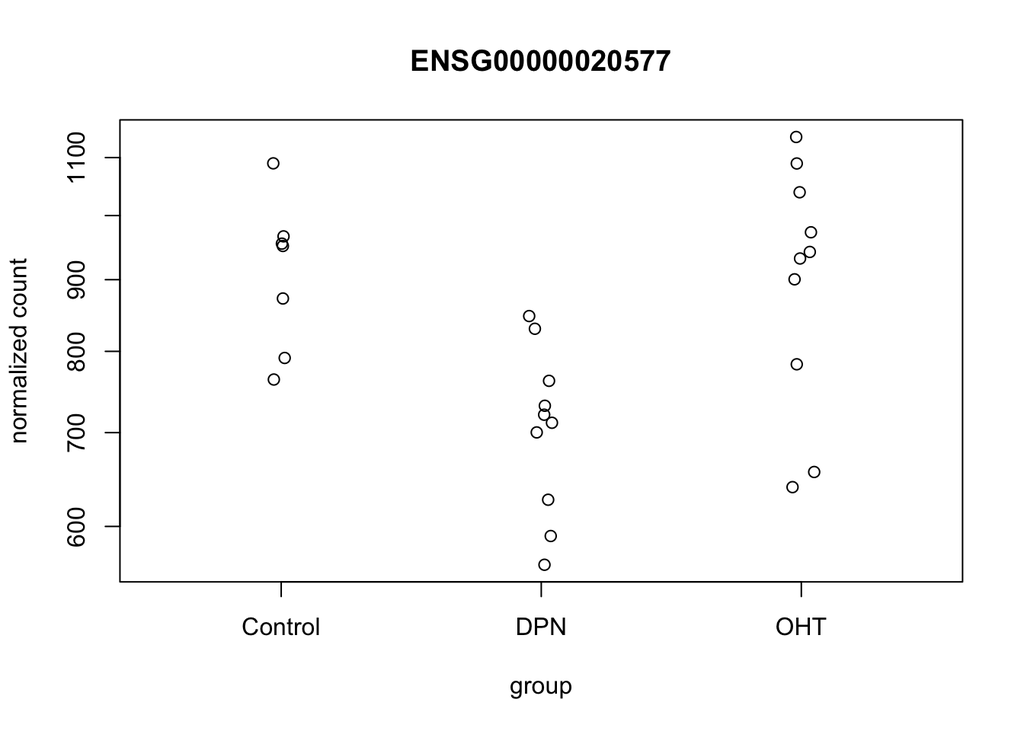

```r
# sanity check - plot the counts for a randomly picked (first) gene in the table
# and see if the pattern makes sense in the light of the estimated LFC values
plotCounts(dds_de,
           gene = rownames(res_filtered)[1],
           intgroup = "treatment")
```

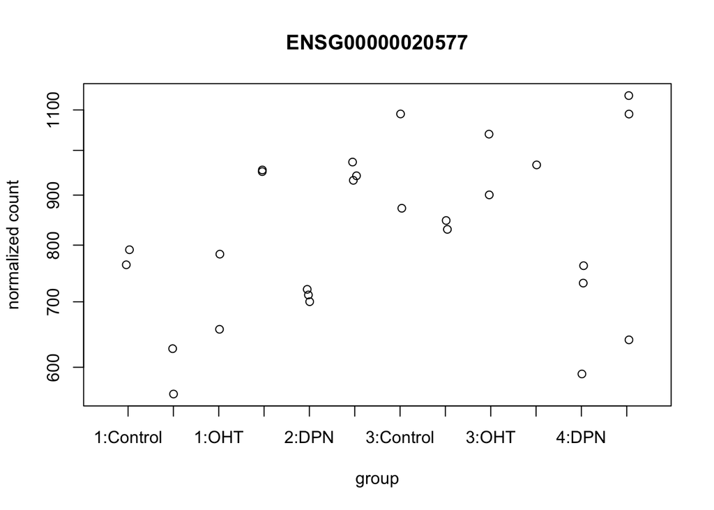

```r
plotCounts(dds_de,
           gene = rownames(res_filtered)[1],
           intgroup = c("patient", "treatment"))
```